# Homework 4

## Problem 1. Random Geometry (2pts each, 8pts total)

Use Monte Carlo simulation to estimate the following geometric properties of shapes and solids. Use the following facts:

- The distance between $(x_1,y_1)$ and $(x_2,y_2)$ is $\sqrt{(x_2-x_1)^2+(y_2-y_1)^2}$
- The coordinates of a point on a unit circle at angle $\theta$ is $(\cos\theta,\sin\theta)$
- The area of a triangle with vertices $(x_i, y_i), i=1,2,3$ is $\frac12 \left|x_1(y_2 − y_3) + x_2(y_3 − y_1) + x_3(y_1 − y_2)\right|$
1. What is the the average distance between two points in a box with side lengths 5, 10 and 20?

```r
x1 = runif(1e6, 0, 5)
x2 = runif(1e6, 0, 5)
y1 = runif(1e6, 0, 10)
y2 = runif(1e6, 0, 10)
z1 = runif(1e6, 0, 20)
z2 = runif(1e6, 0, 20)
mean(sqrt((x2 - x1)^2 + (y2 - y1)^2 + (z2 - z1)^2))
```

```
## [1] 8.377939
```

2. Three points uniformly at random are selected on a circle with radius 1. What is the average area of the triangle formed?

```r
x1 = cos(runif(1e6, 0, 2 * pi))
x2 = cos(runif(1e6, 0, 2 * pi))
x3 = cos(runif(1e6, 0, 2 * pi))
y1 = sin(runif(1e6, 0, 2 * pi))
y2 = sin(runif(1e6, 0, 2 * pi))
y3 = sin(runif(1e6, 0, 2 * pi))
mean(abs(x1 * (y2 - y3) + x2 * (y3-y1) + x3 * (y1-y2))/2)
```

```
## [1] 0.4601175
```

3. Three points uniformly at random are selected on a circle with radius 1. What is the average perimeter of the triangle formed?

```r
x1 = cos(runif(1e6, 0, 2 * pi))
x2 = cos(runif(1e6, 0, 2 * pi))
x3 = cos(runif(1e6, 0, 2 * pi))
y1 = sin(runif(1e6, 0, 2 * pi))
y2 = sin(runif(1e6, 0, 2 * pi))
y3 = sin(runif(1e6, 0, 2 * pi))
mean(sqrt((x2 - x1)^2 + (y2 - y1)^2)) + mean(sqrt((x2 - x3)^2 + (y2 - y3)^2)) + mean(sqrt((x3 - x1)^2 + (y3 - y1)^2))
```

```
## [1] 3.833735
```

4. Let $(X,Y)$ be a random point, where both $X$ and $Y$ are independent, standard normal random variables. What is the average distance between $(X_1,Y_1)$ and $(X_2,Y_2)$?

```r
x1 = rnorm(1e6)
x2 = rnorm(1e6)
y1 = rnorm(1e6)
y2 = rnorm(1e6)
mean(sqrt((x2 - x1)^2 + (y2 - y1)^2))
```

```
## [1] 1.772236
```

## Problem 2: Law of Large Numbers (1.5pts each, 7.5pts total)

For this next problem, we’re going to empirically demonstrate the law of large numbers by simulating $N$ observations of a random variable, and show the convergence of the sample mean to the theoretical mean. Consider a Poisson variable $X$ with $\lambda=13$. It should hopefully be clear from the definition of the Poisson that $E(X)=\lambda=13$.

1. Start by creating a data frame with 2 columns: a column named `n` that goes from 1, 2, …, up to 1000; and a second column named `x` which is just 1000 repeated observations of a Poisson random variable with `lambda=13`.

```r
poisson = tibble(n = 1:1000, x = rpois(1000, 13))
poisson
```

```
## # A tibble: 1,000 × 2
##        n     x
##    <int> <int>
##  1     1    16
##  2     2    13
##  3     3    13
##  4     4    14
##  5     5    14
##  6     6     9
##  7     7    20
##  8     8     5
##  9     9    11
## 10    10    21
## # ℹ 990 more rows
```

2. Next, create a third column named `xbar` that computes the “mean-thus-far” up to each row. E.g. if the first 3 values of `x` are 3, 1, 8, then the first 3 values of `xbar` should be 3, 2, 4, since 3=3, (3+1)/2=2, and (3+1+8)/3=4. (Hint: use the `cumsum()` function to take the cumulative sum of the `x` column, then divide by the number of observations so far)

```r
poisson = poisson %>% mutate(xbar = cumsum(x) / n)
poisson
```

```
## # A tibble: 1,000 × 3
##        n     x  xbar
##    <int> <int> <dbl>
##  1     1    16  16
##  2     2    13  14.5
##  3     3    13  14
##  4     4    14  14
##  5     5    14  14
##  6     6     9  13.2
##  7     7    20  14.1
##  8     8     5  13
##  9     9    11  12.8
## 10    10    21  13.6
## # ℹ 990 more rows
```

3. Make a line plot showing xbar vs n. Add a red line at the theoretical mean. Comment on what you observe in the plot. Is this what you were expecting? (Don’t forget to add proper labels/titles).

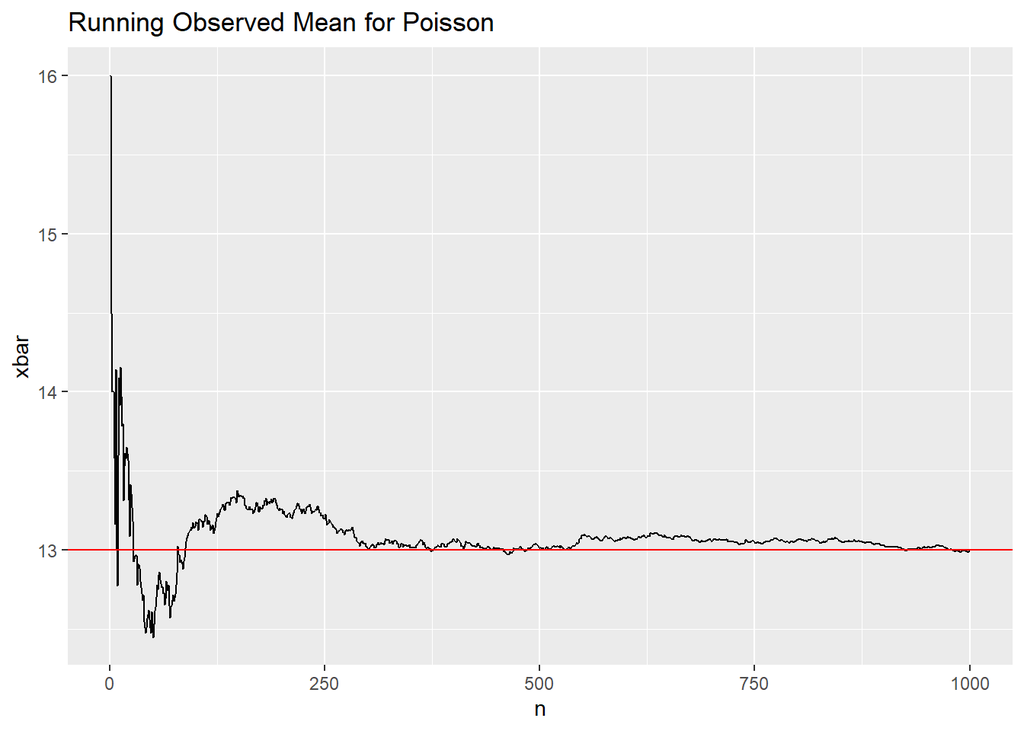

```r
ggplot(poisson, aes(n, xbar)) + geom_line() + geom_hline(yintercept = 13, color = "red") + ggtitle("Running Observed Mean for Poisson")
```

When n is small, there appears to be a large amount of variability. As n increases, the cumulative average seems to be approaching the theoretical at $13$. This agrees with the law of large numbers, which applies to the poisson, so this is expected.

4. Now, increase the number of simulations to 100,000 and remake the plot, this time with a log-scale x-axis to better show the rate of convergence across the entire axis. Comment again on the output. Explain if this does or does not empirically agree with the law of large numbers.

[figure not shown]

```r
poisson = tibble(n = 1:1e5, x = rpois(1e5, 13))
poisson = poisson %>% mutate(xbar = cumsum(x) / n)
ggplot(poisson, aes(n, xbar)) + geom_line() + geom_hline(yintercept = 13, color = "red") + scale_x_log10() + ggtitle("Running Observed Mean for Poisson")
```

The pattern is similar to the previous question, a large amount of variability for small $n$, and the running average approaches the theoretical mean $13$ as $n$ increases. The difference is we can see the observed mean stay around the theoretical mean. This agrees with the law of large numbers since, for a large number of observations, our observed mean is close to the theoretical mean, and is staying that way.

5. Repeat the above steps with a **different** random variable. You can copy your entire code chunk so far and just make the necessary modifications. Comment on this output too and whether or not it also agrees with your expectations. Make sure you CLEARLY define what the random variable you’re using and clearly state what the expected value is (you may look this up on the internet if it’s a new random variable we covered this week that we did not give the expectation formula for in class).

Repeat the steps for $Z$

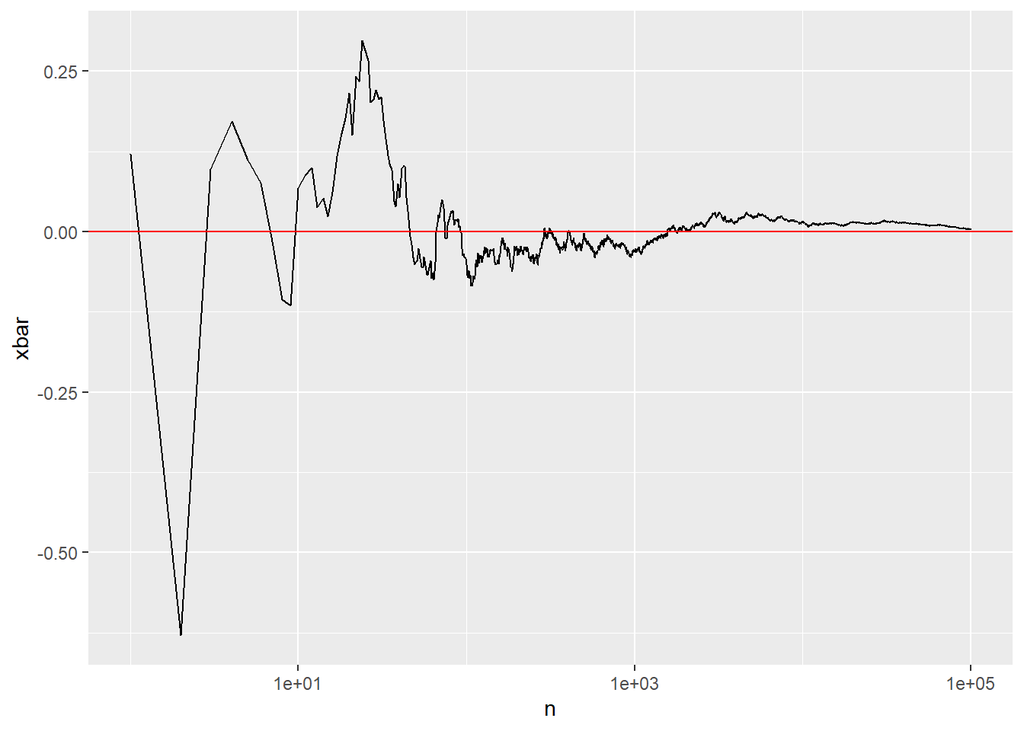

```r
stdn = tibble(n = 1:1e5, x = rnorm(1e5))
stdn = stdn %>% mutate(xbar = cumsum(x) / n)
ggplot(stdn, aes(n, xbar)) + geom_line() + geom_hline(yintercept = 0, color = "red") + scale_x_log10()
```

The pattern involving approaching increasing $n$ approaching the mean applies to this random variable as well. We expect the mean to be $0$, and the cumulative observed average also approaches $0$.

## Problem 3: How Many Billies Can Fit? (1.5pts each, 7.5pts total)

You have an empty wall That is exactly 241 cm wide (with walls on either side). You see that Billy the Bookcase (https://www.ikea.com/us/en/p/billy-bookcase-white-00263850/) is 80cm wide, so you should be able to fit 3 in this space.

Suppose, however that The width of Billy is actually 80cm **on average**. In fact, the width is a normal random variable with a mean of 80 and a standard deviation of .5cm. (Please note - this is fictional! Ikea would never let quality control slip this bad). Use Monte Carlo simulation to answer the following questions:

1. Estimate the expected value and standard deviation for the total width of the 3 Billys.

```r
width_sim = rnorm(1e6, 80, .5) + rnorm(1e6, 80, .5) + rnorm(1e6, 80, .5)
mean(width_sim)
```

```
## [1] 240.0001
```

```r
sd(width_sim)
```

```
## [1] 0.8658763
```

2. If you buy 3 Billys, what is the probability that they will fit on your wall? Assume Billys are independent.

```r
mean(width_sim <= 241)
```

```
## [1] 0.875954
```

3. How wide of a space would you need to be 99% sure that 3 Billys would fit? *Hint: Use the `quantile` function in R*

```r
quantile(width_sim, probs = c(.99))
```

```
##      99%
## 242.0154
```

4. There are two other bookcases made by knockoff brand “Iqueeya”: Goat and Gruff. Goat bookcase widths are normally distributed with a mean of 79cm and a standard deviation of .25cm, while Gruff bookcase widths are normally distributed with a mean of 81cm and a standard deviation of .6cm. What is the probability that a Billy, a Goat and a Gruff will fit on your wall? (Assume independence)

```r
width_sim = rnorm(1e6, 80, .5) + rnorm(1e6, 79, .25) + rnorm(1e6, 81, .6)
mean(width_sim <= 241)
```

```
## [1] 0.889013
```

5. Suppose you want the amount of gap between the bookcases and the side walls to be **as small as possible**. You assess how good of a fit you have by scoring: Buying 3 bookcases gives you a score of 0 if they don’t fit, but otherwise a score of
   $$\frac{\text{total width}}{241}\times
   100.$$
   What combination of Billys, Goats and Gruffs gives you the highest *expected score*?

```
## # A tibble: 10 × 2
##    combs               dists
##    <chr>               <dbl>
##  1 billy, billy, billy 87.3
##  2 billy, billy, goat  98.8
##  3 billy, billy, gruff 50.0
##  4 billy, goat, goat   98.8
##  5 billy, goat, gruff  88.3
##  6 billy, gruff, gruff 15.5
##  7 goat, goat, goat    98.3
##  8 goat, goat, gruff   99.0
##  9 goat, gruff, gruff  49.9
## 10 gruff, gruff, gruff  2.62
```

```
## # A tibble: 1 × 2
##   combs             dists
##   <chr>             <dbl>
## 1 goat, goat, gruff  99.0
```

## Problem 4: Simulating a random variable (7pts)

Define a random variable $X$ with density
$$f_X(t) = \begin{cases}
\frac12\sin t &\mbox{ if } 0 \le t \le \pi \\
0 &\mbox{ otherwise. }
\end{cases}$$

The probability density function (pdf) is visualized below.

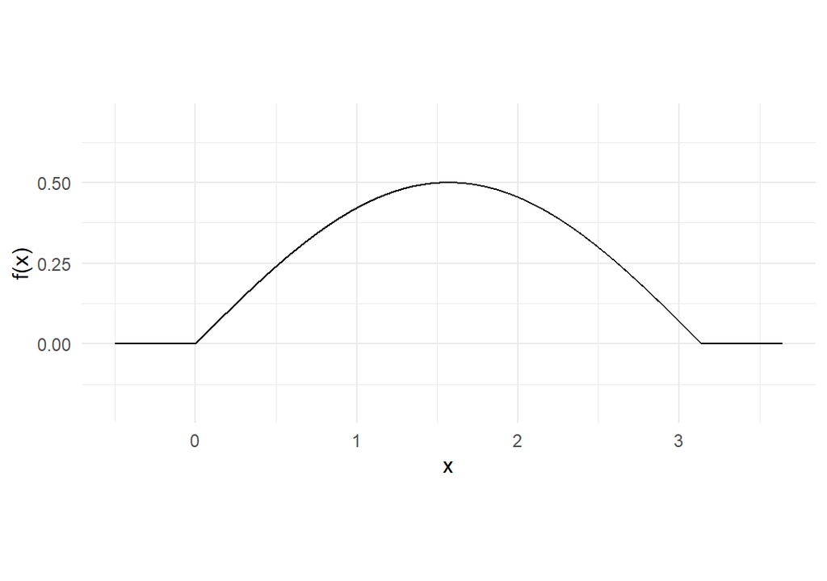

This means that the cumulative distribution function is
$$F_X(t)=\int_0^tf_X(u)du=\frac12-\frac{1}{2}\cos(t)$$
for $0 \le t \le \pi$, (and $F_X(t)=0$ for $t<0$ and $F_X(t) = 1$ for $t \ge \pi$).

1. (3 points) Find $F^{-1}(x)$, the inverse CDF. *Hint: In `R` the `arc-cosine` function is `acos()`.*
2. (4 points) Write a function `rx(n)` (like `rbinom`) to sample from this random variable, where `n` is the size of the sample to be drawn. Then, use your function to draw sample of size 1000 and plot a histogram of the output to verify the results make sense.

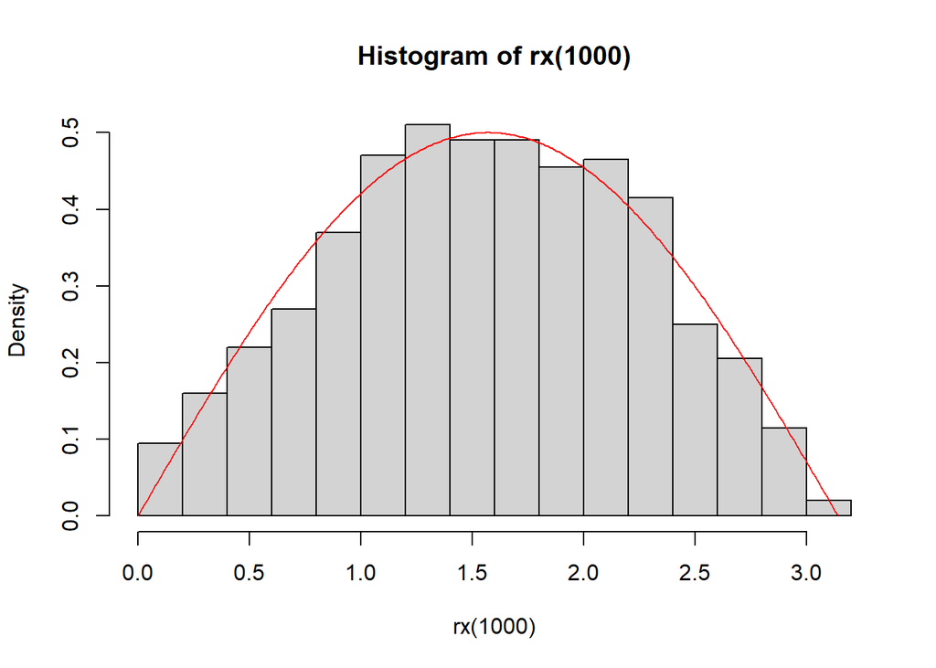

```r
F_inv = function(y) {

  return(ifelse(0<=y & y<=pi , acos(1 - 2 * y) , 0 ))

}
# complete the function
rx = function(n) {
  u <- runif(n)  # Generate n uniform random numbers
  return(F_inv(u))  # Transform them using the inverse CDF
}

# The histogram should look like the PDF we plotted above.
# Un-comment the following lines of code and check it looks correct

hist(rx(1000), probability=TRUE)
lines(x=seq(0,pi,.01), y=pdf_x(seq(0,pi,.01)), col='red')
```